# unified_modeling

```r
setwd("G:/My Drive/academics/2122_uic_ms/2022_spring/ids506_health/prostate")

library(tidyverse)
library(tidymodels)
library(textrecipes)
library(discrim)
library(patchwork)
library(lubridate)
library(tidytext)
library(themis)
library(vip)
library(kableExtra)
```

```r
dat <- read_csv("data/training_data.csv") %>%
  rename(y = survival_7_years) %>%
  mutate(y = y %>% factor()) %>%
  # Removing NAs
  drop_na(
    # No default variables
    weight,height,age,
    # Essential variables
    gleason_score,psa_diagnosis,tumor_diagnosis
  ) %>%
  # Mutations
  mutate(
    # Imputing for PSA and tumor size
    psa_1_year           = case_when(!is.na(psa_1_year)                       ~ psa_1_year,
                                     is.na(psa_1_year) & !is.na(psa_6_months) ~ psa_6_months,
                                     is.na(psa_1_year) & is.na(psa_6_months)  ~ psa_diagnosis,
                                     is.na(psa_1_year) & is.na(psa_6_months) & is.na(psa_diagnosis) ~ 0),
    tumor_1_year         = case_when(!is.na(tumor_1_year)                         ~ tumor_1_year,
                                     is.na(tumor_1_year) & !is.na(tumor_6_months) ~ tumor_6_months,
                                     is.na(tumor_1_year) & is.na(tumor_6_months)  ~ tumor_diagnosis,
                                     is.na(tumor_1_year) & is.na(tumor_6_months) & is.na(tumor_diagnosis) ~ 0),
    # Family History imputation
    family_history       = ifelse(is.na(family_history)==1,       0,family_history),
    family_history       = family_history %>% factor(),
    first_degree_history = ifelse(is.na(first_degree_history)==1, 0,first_degree_history),
    first_degree_history = first_degree_history %>% factor(),
    # Personal History imputation
    previous_cancer      = ifelse(is.na(previous_cancer)==1,      0,previous_cancer),
    smoker               = ifelse(is.na(smoker)==1,               0,smoker)
  )
```

# Splitting

```r
set.seed(8675309)
splits <- initial_split(dat,
                        prop = .8,
                        strata = y)

d.train <- training(splits)
d.test  <- testing(splits)
cv.fold <- vfold_cv(d.train, v = 4)
```

# Processing Recipes

```r
rc_symptoms_only <-
  recipe(y ~ .,data = d.train) %>%
  # Parsing symptoms
  step_tokenize(symptoms,options = list(strip_punct = T,
                                        lowercase   = T)) %>%
  step_tf(symptoms)

rc <- rc_symptoms_only %>%
  # Removing unused features
  step_rm(id,diagnosis_date,tumor_6_months,psa_6_months,tea,race) %>%
  # Releveling
  step_relevel(side,    ref_level = "left") %>%
  step_relevel(t_score, ref_level = "T1a") %>%
  step_relevel(n_score, ref_level = "N0") %>%
  step_relevel(m_score, ref_level = "M0") %>%
  step_relevel(stage,   ref_level = "I") %>%
  step_relevel(family_history, ref_level = "0") %>%
  step_relevel(first_degree_history, ref_level = "0") %>%
  # Dummy variable creation
  step_dummy(t_score,n_score,m_score,stage,family_history,first_degree_history,side)

recipe_base <- rc %>%
  step_zv(all_numeric_predictors())

recipe_engi <- rc %>%
  # Mutations
  step_mutate(bmi = 703*weight/(height)^2,
              # Creating weight classes (obese/overweight/underweight/norm)
              wgt_class = case_when(bmi < 18.5~"underweight",
                                    18.5 <= bmi & bmi < 25 ~ "normal",
                                    25.0 <= bmi & bmi < 30 ~ "overweight",
                                    30.0 <= bmi ~ "obese"),
              wgt_class = wgt_class %>% factor(),
              # Creating PSA/tumor size delta (is it growing?)
              psa_delta1   = psa_1_year - psa_diagnosis,
              tumor_delta1 = tumor_1_year - tumor_diagnosis) %>%
  # Releveling for wgt_class
  step_relevel(wgt_class, ref_level = "normal") %>%
  # Dummy for weight classes
  step_dummy(wgt_class) %>%
  # Removing unused height/weight/bmi to keep engineered features
  step_rm(height,weight,bmi) %>%
  step_zv(all_numeric_predictors())

recipe_engi_norm <- recipe_engi %>% step_normalize(all_numeric_predictors())
```

```r
rc_symptoms_only
```

```
## Recipe
##
## Inputs:
##
##       role #variables
##    outcome          1
##  predictor         32
##
## Operations:
##
## Tokenization for symptoms
## Term frequency with symptoms
```

```r
recipe_base
```

```
## Recipe
##
## Inputs:
##
##       role #variables
##    outcome          1
##  predictor         32
##
## Operations:
##
## Tokenization for symptoms
## Term frequency with symptoms
## Delete terms id, diagnosis_date, tumor_6_months, psa_6_months, tea, ...
## Re-order factor level to ref_level for side
## Re-order factor level to ref_level for t_score
## Re-order factor level to ref_level for n_score
## Re-order factor level to ref_level for m_score
## Re-order factor level to ref_level for stage
## Re-order factor level to ref_level for family_history
## Re-order factor level to ref_level for first_degree_history
## Dummy variables from t_score, n_score, m_score, stage, family_history, first_d...
## Zero variance filter on all_numeric_predictors()
```

```r
recipe_engi
```

```
## Recipe
##
## Inputs:
##
##       role #variables
##    outcome          1
##  predictor         32
##
## Operations:
##
## Tokenization for symptoms
## Term frequency with symptoms
## Delete terms id, diagnosis_date, tumor_6_months, psa_6_months, tea, ...
## Re-order factor level to ref_level for side
## Re-order factor level to ref_level for t_score
## Re-order factor level to ref_level for n_score
## Re-order factor level to ref_level for m_score
## Re-order factor level to ref_level for stage
## Re-order factor level to ref_level for family_history
## Re-order factor level to ref_level for first_degree_history
## Dummy variables from t_score, n_score, m_score, stage, family_history, first_d...
## Variable mutation
## Re-order factor level to ref_level for wgt_class
## Dummy variables from wgt_class
## Delete terms height, weight, bmi
## Zero variance filter on all_numeric_predictors()
```

```r
recipe_engi_norm
```

```
## Recipe
##
## Inputs:
##
##       role #variables
##    outcome          1
##  predictor         32
##
## Operations:
##
## Tokenization for symptoms
## Term frequency with symptoms
## Delete terms id, diagnosis_date, tumor_6_months, psa_6_months, tea, ...
## Re-order factor level to ref_level for side
## Re-order factor level to ref_level for t_score
## Re-order factor level to ref_level for n_score
## Re-order factor level to ref_level for m_score
## Re-order factor level to ref_level for stage
## Re-order factor level to ref_level for family_history
## Re-order factor level to ref_level for first_degree_history
## Dummy variables from t_score, n_score, m_score, stage, family_history, first_d...
## Variable mutation
## Re-order factor level to ref_level for wgt_class
## Dummy variables from wgt_class
## Delete terms height, weight, bmi
## Zero variance filter on all_numeric_predictors()
## Centering and scaling for all_numeric_predictors()
```

# Simple Models

## Blind Model

```r
probs.train <- d.train %>% group_by(y) %>% summarise(n=n()) %>% transmute(prop = n/sum(n)) %>% .$prop

blind <- function(dframe){
  dframe %>%
    mutate(
      y_hat = sample(c("0","1"), replace = T, prob = probs.train, size = nrow(dframe))
    )
}

set.seed(8675309)
blind(d.test) %>%
  mutate(y_hat = y_hat %>% factor()) %>%
  accuracy(truth = y,
           estimate = y_hat,
           event_level = "first") %>%
  rbind(
    blind(d.test) %>%
      mutate(y_hat = y_hat %>% factor()) %>%
      f_meas(truth = y,
              estimate = y_hat,
              event_level = "first")
  ) %>%
  mutate(model = "Naive Sampling") %>%
  select(model, .metric,.estimate) %>%
  kbl() %>% kable_minimal(bootstrap_options = "striped", full_width = F)
```

| model | .metric | .estimate |
| --- | --- | --- |
| Naive Sampling | accuracy | 0.4990575 |
| Naive Sampling | f_meas | 0.5857084 |

## Manual Model

```r
manual1 <- function(dframe) {
  dframe %>%
    mutate(
      y_hat = case_when(
        # 1-yr Dead Rule
        survival_1_year == 0 ~ 0,
        # Stage Rule
        stage %in% c("IIB", "III", "IV") ~ 0,
        # Metastatisation Rule
        m_score != "M0" ~ 0,
        n_score != "N0" ~ 0,

        # Symptoms Rule
        `tf_symptoms_o01` == 1 ~ 0,
        `tf_symptoms_o08` == 1 ~ 0,
        `tf_symptoms_o09` == 1 ~ 0,
        `tf_symptoms_o10` == 1 ~ 0,
        `tf_symptoms_p01` == 1 ~ 0,
        `tf_symptoms_p02` == 1 ~ 0,
        `tf_symptoms_p03` == 1 ~ 0,
        `tf_symptoms_s10` == 1 ~ 0,
        TRUE ~ 1
      )
    )
}

d.test.proc <- rc_symptoms_only %>% prep() %>% bake(d.test)

set.seed(8675309)
manual1(d.test.proc) %>%
  mutate(y_hat = y_hat %>% factor()) %>%
  accuracy(truth = y,
           estimate = y_hat,
           event_level = "first") %>%
  rbind(
    manual1(d.test.proc) %>%
      mutate(y_hat = y_hat %>% factor()) %>%
      f_meas(truth = y,
              estimate = y_hat,
              event_level = "first")
  ) %>%
  mutate(model = "Manual") %>%
  select(model, .metric,.estimate)%>%
  kbl() %>% kable_minimal(bootstrap_options = "striped", full_width = F)
```

| model | .metric | .estimate |
| --- | --- | --- |
| Manual | accuracy | 0.6140434 |
| Manual | f_meas | 0.7310345 |

## Naive Bayes

```r
model_nb <-
  naive_Bayes() %>%
  set_mode("classification") %>%
  set_engine("naivebayes")

wf_nb <- workflow() %>%
  add_model(model_nb) %>%
  add_recipe(recipe_base)

fit_nb <- wf_nb %>%
  fit(d.train)

fit_nb_test <- wf_nb %>% last_fit(splits)

preds_nb <- fit_nb_test %>% collect_predictions()

preds_nb %>%
  accuracy(truth = y,
           estimate = .pred_class,
           event_level = "first") %>%
  rbind(
    preds_nb %>%
      roc_auc(truth = y,
               estimate = .pred_0,
               event_level = "first")
  ) %>%
  rbind(
    preds_nb %>%
      f_meas(truth = y,
             estimate = .pred_class,
             event_level = "first")
  )%>%
  mutate(model = "Naive Bayes") %>%
  select(model, .metric,.estimate)%>%
  kbl() %>% kable_minimal(bootstrap_options = "striped", full_width = F)
```

| model | .metric | .estimate |
| --- | --- | --- |
| Naive Bayes | accuracy | 0.5730443 |
| Naive Bayes | roc_auc | 0.7202052 |
| Naive Bayes | f_meas | 0.7224265 |

## Unengineered GLM

```r
model_glm <-
  logistic_reg() %>%
  set_engine("glm")

wf_glm <- workflow() %>%
  add_model(model_glm) %>%
  add_recipe(recipe_base)

fit_glm <- wf_glm %>%
  fit(d.train)
tidy(fit_glm) %>%
  mutate(odds_ratio = round(exp(estimate),2)) %>%
  mutate(sig        = case_when(p.value <= .001 ~ "***",
                                p.value <= .01 & p.value > 0.001 ~ "**",
                                p.value <= .05 & p.value > 0.01 ~ "*")) %>%
  select(term, odds_ratio, p.value, sig) %>%
  filter(term != "(Intercept)") %>%
  arrange(p.value)%>%
  kbl() %>% kable_minimal(bootstrap_options = "striped", full_width = F)
```

term

odds_ratio

p.value

sig

n_score_N1

0.44

0.0000000

***

gleason_score

0.89

0.0000000

***

tumor_1_year

0.99

0.0000000

***

tf_symptoms_u05

0.65

0.0000002

***

rd_thrpy

0.75

0.0000134

***

tf_symptoms_s10

0.64

0.0001020

***

rad_rem

0.79

0.0012385

weight

0.99

0.0012616

brch_thrpy

0.81

0.0020365

tf_symptoms_p02

0.40

0.0161728

stage_IV

0.59

0.0193938

tf_symptoms_p03

0.32

0.0226686

tf_symptoms_p01

0.47

0.0358921

tf_symptoms_o08

0.53

0.0473026

psa_1_year

1.02

0.0486929

tf_symptoms_o09

0.45

0.0512647

NA

tumor_diagnosis

1.00

0.0574091

NA

psa_diagnosis

0.98

0.1184066

NA

family_history_X1

0.91

0.1842006

NA

multi_thrpy

0.89

0.1885258

NA

chm_thrpy

1.09

0.2014853

NA

t_score_T4

1.27

0.2058528

NA

height

1.03

0.2060994

NA

tf_symptoms_s04

1.07

0.2171807

NA

stage_IIB

0.83

0.2439928

NA

family_history_X2

1.19

0.2711855

NA

smoker

1.13

0.2940133

NA

t_score_T1c

0.88

0.3313049

NA

t_score_T2a

1.12

0.3552676

NA

t_score_T3b

1.19

0.3816392

NA

t_score_T1b

1.12

0.3879102

NA

t_score_T3a

1.18

0.4140140

NA

first_degree_history_X2

0.81

0.4230791

NA

family_history_X4

2.60

0.4681217

NA

n_score_NX

1.06

0.4759163

NA

h_thrpy

1.05

0.4765528

NA

tf_symptoms_s07

1.03

0.5272176

NA

first_degree_history_X3

0.65

0.5368233

NA

tf_symptoms_o11

0.96

0.5388282

NA

side_both

1.04

0.5445980

NA

cry_thrpy

0.96

0.5769116

NA

tf_symptoms_u06

0.97

0.5799933

NA

age

1.00

0.6246617

NA

stage_IIA

0.93

0.6524930

NA

tf_symptoms_u01

0.98

0.7465351

NA

tf_symptoms_u02

1.01

0.7677335

NA

stage_III

0.94

0.7781548

NA

previous_cancer

0.97

0.7986280

NA

first_degree_history_X1

1.02

0.8181557

NA

t_score_T2b

0.98

0.8508503

NA

tf_symptoms_o10

0.94

0.8547959

NA

m_score_M1c

1.06

0.8694139

NA

family_history_X3

1.07

0.8724374

NA

t_score_T2c

0.98

0.8839752

NA

t_score_T3c

1.03

0.8852562

NA

survival_1_year

28805702.20

0.8890358

NA

tf_symptoms_o01

1.03

0.9029213

NA

m_score_M1a

1.03

0.9370325

NA

side_right

1.00

0.9687978

NA

m_score_M1b

1.01

0.9819248

NA

tf_symptoms_u03

1.00

0.9918245

NA

first_degree_history_X4

0.00

0.9925122

NA

family_history_X5

0.00

0.9940709

NA

```r
fit_glm_test <- wf_glm %>% last_fit(splits)
```

```
## ! train/test split: preprocessor 1/1, model 1/1: glm.fit: fitted probabilities numerically 0...
```

```r
preds_glm <- fit_glm_test %>% collect_predictions()

preds_glm %>%
  accuracy(truth = y,
           estimate = .pred_class,
           event_level = "first") %>%
  rbind(
    preds_glm %>%
      roc_auc(truth = y,
               estimate = .pred_0,
               event_level = "first")
  ) %>%
  mutate(model = "base-GLM") %>%
  select(model, .metric,.estimate)%>%
  kbl() %>% kable_minimal(bootstrap_options = "striped", full_width = F)
```

| model | .metric | .estimate |
| --- | --- | --- |
| base-GLM | accuracy | 0.6743638 |
| base-GLM | roc_auc | 0.7408650 |

# Feature-Engineered Models

## Engineered unregularised GLM

```r
wf_glm_engi <- workflow() %>%
  add_model(model_glm) %>%
  add_recipe(recipe_engi_norm)

fit_glm_engi <- wf_glm_engi %>%
  fit(d.train)
tidy(fit_glm_engi) %>%
  mutate(sig        = case_when(p.value <= .001 ~ "***",
                                p.value <= .01 & p.value > 0.001 ~ "**",
                                p.value <= .05 & p.value > 0.01 ~ "*")) %>%
  select(term, estimate, p.value, sig) %>%
  filter(term != "(Intercept)") %>%
  arrange(p.value)%>%
  kbl() %>% kable_minimal(bootstrap_options = "striped", full_width = F)
```

term

estimate

p.value

sig

n_score_N1

-0.3688596

0.0000000

***

gleason_score

-0.2207874

0.0000000

***

tumor_1_year

-0.3135726

0.0000000

***

tf_symptoms_u05

-0.1323507

0.0000002

***

rd_thrpy

-0.1435097

0.0000122

***

tf_symptoms_s10

-0.1026216

0.0000985

***

wgt_class_obese

-0.0924944

0.0004049

***

rad_rem

-0.0921186

0.0012108

brch_thrpy

-0.0868727

0.0024341

tf_symptoms_p02

-0.1443258

0.0163629

stage_IV

-0.2623332

0.0201941

tf_symptoms_p03

-0.1013726

0.0226331

tf_symptoms_p01

-0.1411708

0.0375169

tf_symptoms_o08

-0.0797713

0.0483832

tf_symptoms_o09

-0.0861743

0.0518590

NA

psa_1_year

0.1051010

0.0558306

NA

tumor_diagnosis

0.0783049

0.0645488

NA

psa_diagnosis

-0.0721803

0.1214402

NA

wgt_class_overweight

-0.0383460

0.1353304

NA

multi_thrpy

-0.0480889

0.1869758

NA

family_history_X1

-0.0410113

0.1975288

NA

chm_thrpy

0.0399140

0.2082004

NA

t_score_T4

0.1022648

0.2150202

NA

tf_symptoms_s04

0.0297186

0.2238397

NA

stage_IIB

-0.0780846

0.2376558

NA

family_history_X2

0.0334130

0.2663491

NA

smoker

0.0255581

0.3053748

NA

t_score_T1c

-0.0317747

0.3204114

NA

t_score_T2a

0.0315165

0.3727212

NA

t_score_T1b

0.0276317

0.3913015

NA

t_score_T3b

0.0520422

0.3970837

NA

first_degree_history_X2

-0.0244278

0.4188840

NA

t_score_T3a

0.0493365

0.4241007

NA

h_thrpy

0.0224488

0.4531665

NA

family_history_X4

0.0255673

0.4646556

NA

n_score_NX

0.0175745

0.4996148

NA

tf_symptoms_s07

0.0159987

0.5130460

NA

tf_symptoms_o11

-0.0156341

0.5222894

NA

side_both

0.0202363

0.5362552

NA

first_degree_history_X3

-0.0178864

0.5428275

NA

tf_symptoms_u06

-0.0137715

0.5737285

NA

cry_thrpy

-0.0151701

0.5974319

NA

age

-0.0119362

0.6308908

NA

stage_IIA

-0.0236779

0.6515340

NA

tf_symptoms_u01

-0.0090025

0.7131439

NA

stage_III

-0.0232272

0.7874627

NA

tf_symptoms_u02

0.0064651

0.7920971

NA

t_score_T2b

-0.0087035

0.8059610

NA

previous_cancer

-0.0059006

0.8134391

NA

tf_symptoms_o10

-0.0065760

0.8447064

NA

first_degree_history_X1

0.0060507

0.8504717

NA

family_history_X3

0.0050882

0.8715177

NA

t_score_T2c

-0.0057537

0.8746700

NA

m_score_M1c

0.0100146

0.8786527

NA

t_score_T3c

0.0069180

0.9082422

NA

tf_symptoms_o01

0.0041043

0.9109765

NA

survival_1_year

6.8274172

0.9260071

NA

wgt_class_underweight

0.2234454

0.9450724

NA

m_score_M1a

0.0024016

0.9686190

NA

tf_symptoms_u03

-0.0008625

0.9719318

NA

side_right

-0.0011408

0.9723340

NA

m_score_M1b

0.0013727

0.9799937

NA

first_degree_history_X4

-0.3434569

0.9951755

NA

family_history_X5

-0.2494411

0.9961230

NA

psa_delta1

NA

NA

NA

tumor_delta1

NA

NA

NA

```r
fit_glm_engi_test <- wf_glm_engi %>% last_fit(splits)
```

```
## ! train/test split: preprocessor 1/1, model 1/1: glm.fit: fitted probabilities numerically 0...
```

```
## ! train/test split: preprocessor 1/1, model 1/1 (predictions): prediction from a rank-defici...
```

```r
preds_glm_engi <- fit_glm_engi_test %>% collect_predictions()

preds_glm_engi %>%
  accuracy(truth = y,
           estimate = .pred_class,
           event_level = "first") %>%
  rbind(
    preds_glm_engi %>%
      roc_auc(truth = y,
               estimate = .pred_0,
               event_level = "first")
  ) %>%
  mutate(model = "engineered-GLM") %>%
  select(model, .metric,.estimate)%>%
  kbl() %>% kable_minimal(bootstrap_options = "striped", full_width = F)
```

| model | .metric | .estimate |
| --- | --- | --- |
| engineered-GLM | accuracy | 0.6757776 |
| engineered-GLM | roc_auc | 0.7421059 |

## Elastic-net GLM

```r
model_glmnet_elastic <-
  logistic_reg(
    penalty = tune(),
    mixture = tune()
  ) %>%
  set_engine("glmnet")

wf_glmnet_elastic <- workflow() %>%
  add_model(model_glmnet_elastic) %>%
  add_recipe(recipe_engi_norm)

grid_glmnet_elastic <- grid_regular(
  penalty(),
  mixture(),
  levels = 6
)
```

```r
set.seed(8675309)
tune_glmnet_elastic <- wf_glmnet_elastic %>%
  tune_grid(resamples = cv.fold,
            grid = grid_glmnet_elastic,
            control = control_grid(save_pred = T),
            metrics = metric_set(accuracy))

write_rds(tune_glmnet_elastic,"models/tuning/tune_glmnet_elastic.rds")
```

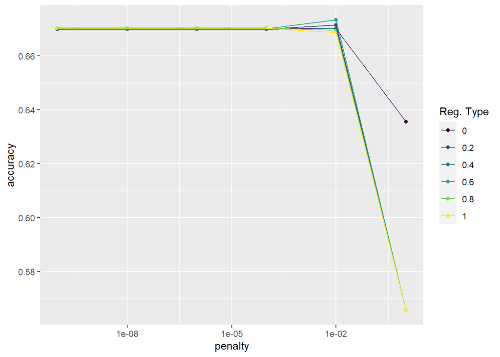

```r
tune_glmnet_elastic <- read_rds("models/tuning/tune_glmnet_elastic.rds")

best_glmnet_elastic <- tune_glmnet_elastic %>%
  select_best(metric = "accuracy")

tune_glmnet_elastic %>%
  collect_metrics() %>%
  ggplot(aes(x = penalty,
             y = mean,
             col = mixture %>% factor())) +
  geom_point()+
  geom_line()+
  labs(
    y = "accuracy",
    col = "Reg. Type"
  )+
  scale_x_log10()+
  scale_color_viridis_d()
```

```r
lastfit_glmnet_elastic <- wf_glmnet_elastic %>%
  finalize_workflow(best_glmnet_elastic) %>%
  last_fit(splits)

lastfit_glmnet_elastic %>%
  extract_workflow() %>%
  tidy() %>%
  select(-penalty) %>%
  filter(term != "(Intercept)") %>%
  arrange(desc(abs(estimate)))%>%
  kbl() %>% kable_minimal(bootstrap_options = "striped", full_width = F)
```

| term | estimate |
| --- | --- |
| survival_1_year | 0.9837585 |
| n_score_N1 | -0.3640233 |
| gleason_score | -0.2035380 |
| tumor_1_year | -0.1341893 |
| rd_thrpy | -0.1143969 |
| tf_symptoms_p01 | -0.1019169 |
| tf_symptoms_u05 | -0.0986897 |
| tf_symptoms_p02 | -0.0930415 |
| tumor_delta1 | -0.0741324 |
| tf_symptoms_s10 | -0.0699019 |
| stage_III | 0.0565106 |
| tf_symptoms_p03 | -0.0533405 |
| stage_IV | -0.0532372 |
| rad_rem | -0.0516380 |
| wgt_class_obese | -0.0467116 |
| tf_symptoms_o08 | -0.0464231 |
| tf_symptoms_o09 | -0.0384841 |
| brch_thrpy | -0.0321105 |
| multi_thrpy | -0.0207395 |
| m_score_M1b | -0.0100925 |
| m_score_M1a | -0.0097641 |
| family_history_X1 | -0.0096943 |
| stage_IIB | -0.0091137 |
| t_score_T1c | -0.0070674 |
| m_score_M1c | -0.0051965 |
| t_score_T3c | -0.0025840 |
| t_score_T1b | 0.0018512 |
| wgt_class_underweight | 0.0005630 |
| t_score_T2a | 0.0003439 |
| age | 0.0000000 |
| previous_cancer | 0.0000000 |
| smoker | 0.0000000 |
| tumor_diagnosis | 0.0000000 |
| psa_diagnosis | 0.0000000 |
| psa_1_year | 0.0000000 |
| h_thrpy | 0.0000000 |
| chm_thrpy | 0.0000000 |
| cry_thrpy | 0.0000000 |
| tf_symptoms_o01 | 0.0000000 |
| tf_symptoms_o10 | 0.0000000 |
| tf_symptoms_o11 | 0.0000000 |
| tf_symptoms_s04 | 0.0000000 |
| tf_symptoms_s07 | 0.0000000 |
| tf_symptoms_u01 | 0.0000000 |
| tf_symptoms_u02 | 0.0000000 |
| tf_symptoms_u03 | 0.0000000 |
| tf_symptoms_u06 | 0.0000000 |
| t_score_T2b | 0.0000000 |
| t_score_T2c | 0.0000000 |
| t_score_T3a | 0.0000000 |
| t_score_T3b | 0.0000000 |
| t_score_T4 | 0.0000000 |
| n_score_NX | 0.0000000 |
| stage_IIA | 0.0000000 |
| family_history_X2 | 0.0000000 |
| family_history_X3 | 0.0000000 |
| family_history_X4 | 0.0000000 |
| family_history_X5 | 0.0000000 |
| first_degree_history_X1 | 0.0000000 |
| first_degree_history_X2 | 0.0000000 |
| first_degree_history_X3 | 0.0000000 |
| first_degree_history_X4 | 0.0000000 |
| side_both | 0.0000000 |
| side_right | 0.0000000 |
| psa_delta1 | 0.0000000 |
| wgt_class_overweight | 0.0000000 |

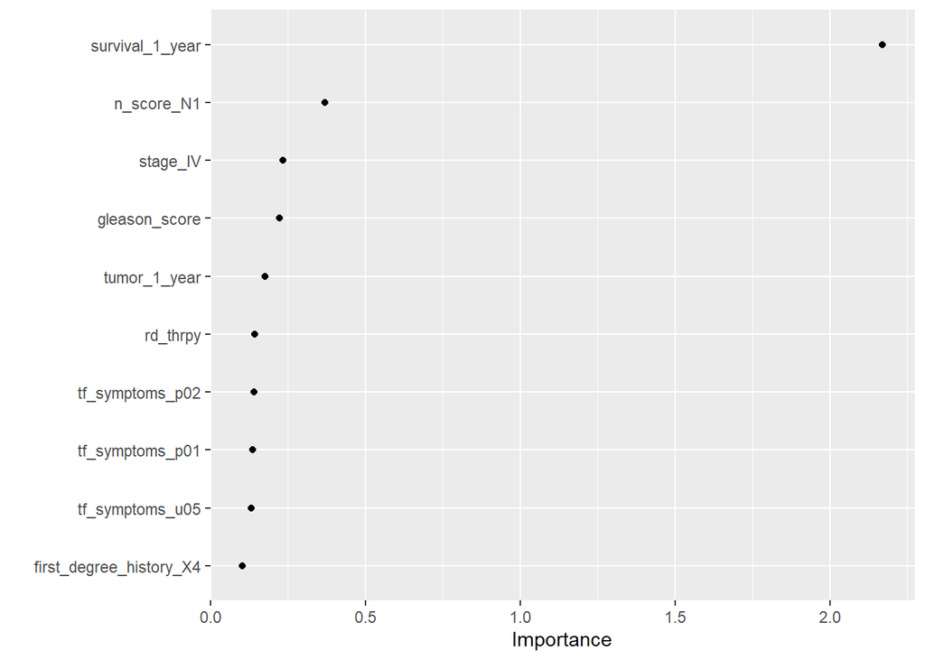

```r
fit_glmnet_elastic <- wf_glmnet_elastic %>%
  finalize_workflow(best_glmnet_elastic) %>%
  fit(data = d.train)

fit_glmnet_elastic %>%
  pull_workflow_fit() %>%
  vip(geom = "point")
```

## xgBoost

```r
model_xgboost <-
  boost_tree(
    trees      = 1000,
    tree_depth = tune(),
    min_n      = tune(),
    loss_reduction = tune(),
    sample_size = tune(),
    mtry       = tune(),
    learn_rate = tune()
  ) %>%
  set_engine("xgboost") %>%
  set_mode("classification")

wf_xgboost <- workflow() %>%
  add_model(model_xgboost) %>%
  add_recipe(recipe_engi)

grid_xgboost <- grid_latin_hypercube(
  tree_depth(),
  min_n(),
  loss_reduction(),
  sample_size = sample_prop(),
  finalize(mtry(),d.train),
  learn_rate(),
  size = 36
)
```

```r
set.seed(8675309)
tune_xgboost <- wf_xgboost %>%
  tune_grid(resamples = cv.fold,
            grid = grid_xgboost,
            control = control_grid(save_pred = T),
            metrics = metric_set(accuracy))

write_rds(tune_xgboost,"models/tuning/tune_xgboost.rds")
```

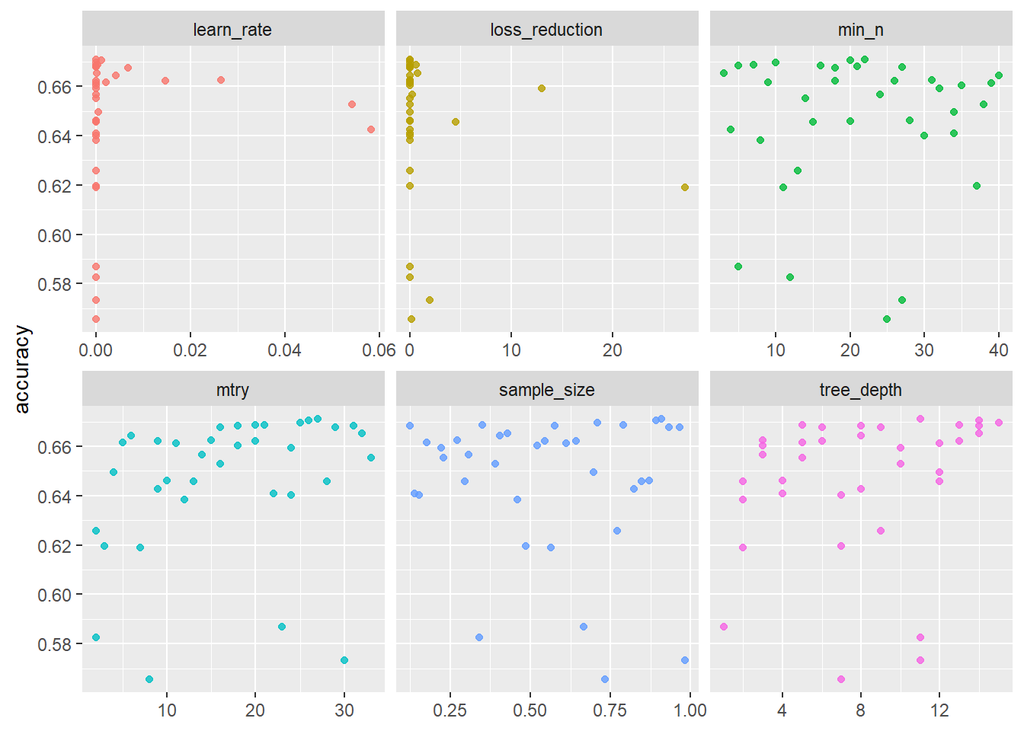

```r
tune_xgboost <- read_rds("models/tuning/tune_xgboost.rds")

best_xgboost <- tune_xgboost %>%
  select_best(metric = "accuracy")

tune_xgboost %>%
  collect_metrics() %>%
  select(mean,mtry:sample_size) %>%
  pivot_longer(mtry:sample_size,
               values_to = "value",
               names_to  = "parameter") %>%
  ggplot(aes(value, mean, color = parameter)) +
  geom_point(alpha = 0.8, show.legend = FALSE) +
  facet_wrap(~parameter, scales = "free_x") +
  labs(x = NULL, y = "accuracy")
```

```r
lastfit_xgboost <- wf_xgboost %>%
  finalize_workflow(best_xgboost) %>%
  last_fit(splits)

fit_xgboost <- wf_xgboost %>%
  finalize_workflow(best_xgboost) %>%
  fit(data = d.train)
```

```
## [01:44:25] WARNING: amalgamation/../src/learner.cc:1115: Starting in XGBoost 1.3.0, the default evaluation metric used with the objective 'binary:logistic' was changed from 'error' to 'logloss'. Explicitly set eval_metric if you'd like to restore the old behavior.
```

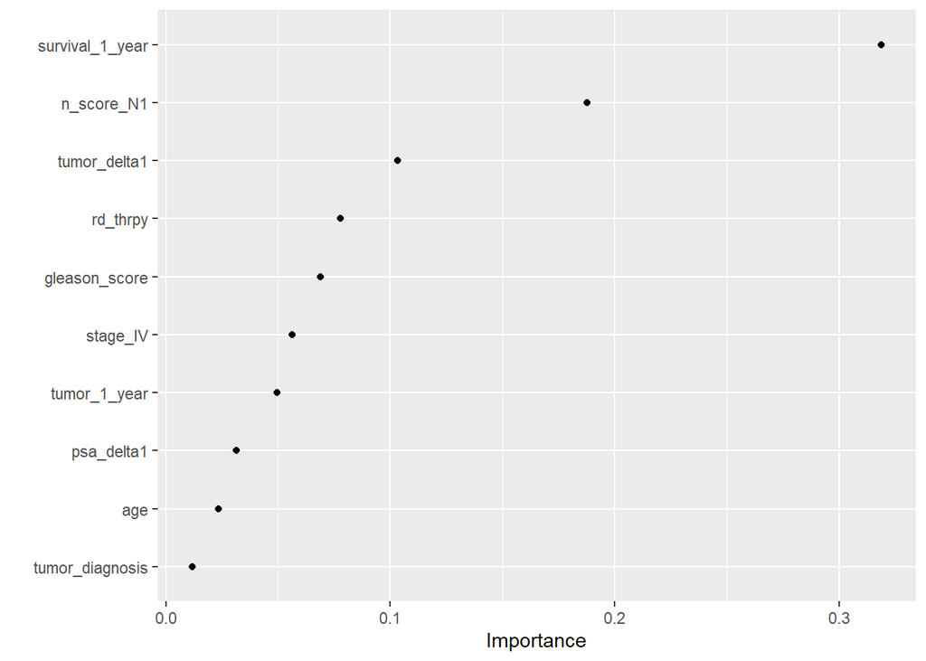

```r
fit_xgboost %>%
  pull_workflow_fit() %>%
  vip(geom = "point")
```

## Screening Step + Model:

```r
# Stacking a check for survival_1_year on top of any fitted model
manual_stack <- function(dframe,modelfit){
  df_man <- dframe[dframe$survival_1_year == min(dframe$survival_1_year),] %>%
    mutate(.pred_class = 0)
  df_alg <- dframe[dframe$survival_1_year != min(dframe$survival_1_year),]
  df_alg <- df_alg %>% cbind(predict(modelfit, new_data = df_alg))

  result <- rbind(df_man,df_alg)
  return(result)
}
```

# Metrics

```r
preds_blind <-
  blind(d.test) %>%
  transmute(.pred_class = y_hat %>% factor(),y=y)

preds_manual1 <-
  manual1(d.test.proc) %>%
  transmute(.pred_class = y_hat %>% factor(),y=y)

preds_nb             <- fit_nb_test            %>% collect_predictions()
preds_glm            <- fit_glm_test           %>% collect_predictions()
preds_glm_engi       <- fit_glm_engi_test      %>% collect_predictions()
preds_glmnet_elastic <- lastfit_glmnet_elastic %>% collect_predictions()
preds_xgboost        <- lastfit_xgboost        %>% collect_predictions()
```

```r
metrics_blind <-
  preds_blind %>% accuracy(truth=y,estimate=.pred_class) %>%
  rbind(preds_blind %>% f_meas(truth=y,estimate=.pred_class)) %>%
  mutate(model = "Naive Sampling") %>%
  select(model, .metric,.estimate) %>%
  pivot_wider(model,names_from=.metric,values_from=.estimate)

metrics_manual1 <-
  preds_manual1 %>% accuracy(truth=y,estimate=.pred_class) %>%
  rbind(preds_manual1 %>% f_meas(truth=y,estimate=.pred_class)) %>%
  mutate(model = "Manual Rules") %>%
  select(model, .metric,.estimate) %>%
  pivot_wider(model,names_from=.metric,values_from=.estimate)

metrics_nb <-
  preds_nb %>% accuracy(truth=y,estimate=.pred_class) %>%
  rbind(preds_nb %>% f_meas(truth=y,estimate=.pred_class)) %>%
  mutate(model = "Naive Bayes") %>%
  select(model, .metric,.estimate) %>%
  pivot_wider(model,names_from=.metric,values_from=.estimate)

metrics_glm <-
  preds_glm %>% accuracy(truth=y,estimate=.pred_class) %>%
  rbind(preds_glm %>% f_meas(truth=y,estimate=.pred_class)) %>%
  mutate(model = "base GLM") %>%
  select(model, .metric,.estimate) %>%
  pivot_wider(model,names_from=.metric,values_from=.estimate)

metrics_glm_engi <-
  preds_glm_engi %>% accuracy(truth=y,estimate=.pred_class) %>%
  rbind(preds_glm_engi %>% f_meas(truth=y,estimate=.pred_class)) %>%
  mutate(model = "engineered GLM") %>%
  select(model, .metric,.estimate) %>%
  pivot_wider(model,names_from=.metric,values_from=.estimate)

metrics_glmnet_elastic <-
  preds_glmnet_elastic %>% accuracy(truth=y,estimate=.pred_class) %>%
  rbind(preds_glmnet_elastic %>% f_meas(truth=y,estimate=.pred_class)) %>%
  mutate(model = "Elastic-net GLM") %>%
  select(model, .metric,.estimate) %>%
  pivot_wider(model,names_from=.metric,values_from=.estimate)

metrics_xgboost <-
  preds_xgboost %>% accuracy(truth=y,estimate=.pred_class) %>%
  rbind(preds_xgboost %>% f_meas(truth=y,estimate=.pred_class)) %>%
  mutate(model = "xgBoost") %>%
  select(model, .metric,.estimate) %>%
  pivot_wider(model,names_from=.metric,values_from=.estimate)
```

```r
tmptable <- metrics_blind %>%
  rbind(metrics_manual1,
        metrics_nb,
        metrics_glm)

tmptable %>%
  mutate(
    lift = (accuracy/min(tmptable$accuracy)-1)
  ) %>%
  arrange(accuracy)%>%
  kbl() %>% kable_minimal(bootstrap_options = "striped", full_width = F)
```

| model | accuracy | f_meas | lift |
| --- | --- | --- | --- |
| Naive Sampling | 0.5113101 | 0.5695309 | 0.0000000 |
| Naive Bayes | 0.5730443 | 0.7224265 | 0.1207373 |
| Manual Rules | 0.6140434 | 0.7310345 | 0.2009217 |
| base GLM | 0.6743638 | 0.7075751 | 0.3188940 |

```r
metrics_table <-
  rbind(metrics_blind,
      metrics_manual1,
      metrics_nb,
      metrics_glm,
      metrics_glm_engi,
      metrics_glmnet_elastic,
      metrics_xgboost)

metrics_table %>%
  mutate(
    lift = (accuracy/min(metrics_table$accuracy)-1)
  ) %>%
  arrange(accuracy)%>%
  kbl() %>% kable_minimal(bootstrap_options = "striped", full_width = F)
```

| model | accuracy | f_meas | lift |
| --- | --- | --- | --- |
| Naive Sampling | 0.5113101 | 0.5695309 | 0.0000000 |
| Naive Bayes | 0.5730443 | 0.7224265 | 0.1207373 |
| Manual Rules | 0.6140434 | 0.7310345 | 0.2009217 |
| base GLM | 0.6743638 | 0.7075751 | 0.3188940 |
| engineered GLM | 0.6757776 | 0.7084746 | 0.3216590 |
| Elastic-net GLM | 0.6795476 | 0.7145256 | 0.3290323 |
| xgBoost | 0.6833176 | 0.7152542 | 0.3364055 |

```r
preds_manual_xgboost <- manual_stack(d.test,fit_xgboost) %>%
  transmute(.pred_class = .pred_class %>% factor(),y=y)

preds_manual_glmnet <- manual_stack(d.test,fit_glmnet_elastic) %>%
  transmute(.pred_class = .pred_class %>% factor(),y=y)

metrics_manual_xgboost <-
  preds_manual_xgboost %>%
  accuracy(truth=y,estimate=.pred_class) %>%
  rbind(preds_manual_xgboost %>% f_meas(truth=y,estimate=.pred_class)) %>%
  mutate(model = "Manual + xgBoost") %>%
  select(model, .metric,.estimate) %>%
  pivot_wider(model,names_from=.metric,values_from=.estimate)

metrics_manual_glmnet <-
  preds_manual_glmnet %>%
  accuracy(truth=y,estimate=.pred_class) %>%
  rbind(preds_manual_glmnet %>% f_meas(truth=y,estimate=.pred_class)) %>%
  mutate(model = "Manual + Elastic-net") %>%
  select(model, .metric,.estimate) %>%
  pivot_wider(model,names_from=.metric,values_from=.estimate)
```

```r
metrics_table %>%
  rbind(metrics_manual_xgboost,
        metrics_manual_glmnet) %>%
  mutate(
    lift = (accuracy/min(metrics_table$accuracy)-1)
  ) %>%
  arrange(accuracy)%>%
  kbl() %>% kable_minimal(bootstrap_options = "striped", full_width = F)
```

| model | accuracy | f_meas | lift |
| --- | --- | --- | --- |
| Naive Sampling | 0.5113101 | 0.5695309 | 0.0000000 |
| Naive Bayes | 0.5730443 | 0.7224265 | 0.1207373 |
| Manual Rules | 0.6140434 | 0.7310345 | 0.2009217 |
| base GLM | 0.6743638 | 0.7075751 | 0.3188940 |
| engineered GLM | 0.6757776 | 0.7084746 | 0.3216590 |
| Elastic-net GLM | 0.6795476 | 0.7145256 | 0.3290323 |
| Manual + Elastic-net | 0.6795476 | 0.7145256 | 0.3290323 |
| xgBoost | 0.6833176 | 0.7152542 | 0.3364055 |
| Manual + xgBoost | 0.6875589 | 0.7187102 | 0.3447005 |